# Case study on Automated Data Collection

Alex Sanchez (adapted from ADC)

June 2018

This case study has been adapted from chapter 1 of the book [Automated Data Collection with R](http://www.r-datacollection.com/) (ADCR, from now on). Its goal is not to be exhaustive but providing a first example of a situation where we obtain and analyze data from the web.

```r
> # load packages
> if (!require(stringr)) install.packages("stringr", dep=TRUE)
> if (!require(XML)) install.packages("XML", dep=TRUE)
> if (!require(maps)) install.packages("maps", dep=TRUE)
>
> require(stringr)
> require(XML)
> require(maps)
```

# Getting the data

We start grabbing the data from the web page https://en.wikipedia.org/wiki/List_of_World_Heritage_in_Danger.

If there are any problems the page can be saved into a local file and scraping performed on a local copy.

```r
> # parsing from HTML file in the web
> # heritage_parsed <- htmlParse("https://en.wikipedia.org/wiki/List_of_World_Heritage_in_Danger", encoding = "UTF-8")
>
> # parsing from locally stored HTML file
> heritage_parsed <- htmlParse("worldheritagedanger.htm")
```

## Parsing the object

We have obtained an object with all that’s in the web page. Next we extract *HTML tables* from this object.

```r
> tables <- readHTMLTable(heritage_parsed, stringsAsFactors = FALSE)
> names(tables)
```

```
[1] "collapsibleTable0" "NULL"              "collapsibleTable1"
[4] "NULL"              "NULL"              "collapsibleTable2"
```

```r
> # extract desired table
> danger_table <- tables[[2]]
>
> # alternatively: directly select second table
> danger_table <- readHTMLTable(heritage_parsed, stringsAsFactors = FALSE, which = 2)
>
> names(danger_table)
```

```
[1] "Name"              "Image"             "Location"
[4] "Criteria"          "Area\r\nha (acre)" "Year (WHS)"
[7] "Endangered"        "Reason"            "Refs"
```

# Data cleansing

Now we have a data.frame that can be explored “as usual”

```r
> # select and rename columns
> danger_table <- danger_table[,c(1,3,4,6,7)]
> colnames(danger_table) <- c("name","locn","crit","yins","yend")
> danger_table$name[1:3]
```

```
[1] "Abu Mena"                        "Air and Ténéré Natural Reserves"
[3] "Ancient City of Aleppo"
```

Additionally, we perform some simple data cleaning, a step often necessary when importing web-based content into R.

- The variable crit, which contains the information whether the site is of cultural or natural character, is recoded,
- and the two variables y_ins and y_end are turned into numeric ones.2
- Some of the entries in the y_end variable are ambiguous as they contain several years. We select the last given year in the cell.
- To do so, we specify a so-called regular expression

```r
> danger_table$crit <- ifelse(str_detect(danger_table$crit, "Natural")==T, "nat", "cult")
> # cleanse years
> danger_table$yins <- as.numeric(danger_table$yins)
> danger_table$yend
```

```
 [1] "2001"            "1992"            "2013"
 [4] "2013"            "2013"            "2013"
 [7] "2003"            "2010"            "2009"
[10] "1986"            "2012"            "2003"
[13] "2005"            "2013"            "2003"
[16] "2013"            "1993–2007, 2010" "2012"
[19] "2005"            "1984–1992, 1996" "2009"
[22] "2000"            "1997"            "2012"
[25] "2009"            "1997"            "2002"
[28] "2006"            "1992"            "2007"
[31] "1997"            "1982"            "2010"
[34] "1996–2007, 2011" "2004"            "1999"
[37] "2007"            "1996"            "2013"
[40] "2012"            "2012"            "2010"
[43] "2011"            "1994"
```

```r
> yend_clean <- unlist(str_extract_all(danger_table$yend, "[[:digit:]]{4}$"))
> danger_table$yend <- as.numeric(yend_clean)
```

The locn variable is a bit of a mess, exemplified by three cases drawn from the data-set:

```r
> danger_table$locn[c(1,3,5)]
```

```
[1] "EgyAbusir, Egypt30°50′30″N 29°39′50″E / 30.84167°N 29.66389°E / 30.84167; 29.66389 (Abu Mena)"
[2] "Syria !Aleppo Governorate,  Syria36°14′0″N 37°10′0″E / 36.23333°N 37.16667°E / 36.23333; 37.16667 (Ancient City of Aleppo)"
[3] "Syria !Damascus Governorate,  Syria33°30′41″N 36°18′23″E / 33.51139°N 36.30639°E / 33.51139; 36.30639 (Ancient City of Damascus)"
```

The variable contains the name of the site’s location, the country, and the geographic coordinates in several varieties. What we need for the map are the coordinates, given by the latitude (e.g., 30.84167N) and longitude (e.g., 29.66389E) values.

To extract this information, we have to use some more advanced text manipulation tools called “regular expressions”.

In short, we have to give R an exact description of what the information we are interested in looks like, and then let R search for and extract it.

To do so, we use functions from the stringr package. In order to get the latitude and longitude values, we write the following:

```r
> # get countries
> reg <- "[[:alpha:] ]+(?=[[:digit:]])"
> country <- str_extract(danger_table$locn , reg)
> # use forward assertion in Perl regular expression
> country
```

```
 [1] "Egypt"                            "Niger"
 [3] "Syria"                            "Syria"
 [5] "Syria"                            "Syria"
 [7] "Iraq"                             "Georgia"
 [9] "Belize"                           "Peru"
[11] "Palestine"                        "Ivoire"
[13] "Venezuela"                        "Syria"
[15] "Afghanistan"                      "Solomon Islands"
[17] "United States"                    "Panama"
[19] "Chile"                            "Democratic Republic of the Congo"
[21] "Georgia"                          "Yemen"
[23] "Democratic Republic of the Congo" "United Kingdom"
[25] "Colombia"                         "Central African Republic"
[27] "Afghanistan"                      "Serbia"
[29] "N "                               "Senegal"
[31] "Democratic Republic of the Congo" "nb "
[33] "Madagascar"                       "Honduras"
[35] "Tanzania"                         "Democratic Republic of the Congo"
[37] "Iraq"                             "Ethiopia"
[39] "Syria"                            "Mali"
[41] "Mali"                             "Uganda"
[43] "Indonesia"                        "Democratic Republic of the Congo"
```

```r
> country[29] <- "C?te d'Ivoire / Guinea"
> country[32] <- ""
> danger_table$country <- country
>
> # get coordinates
> reg_y <- "[/][ -]*[[:digit:]]*[.]*[[:digit:]]*[;]"
> reg_x <- "[;][ -]*[[:digit:]]*[.]*[[:digit:]]*"
> y_coords <- str_extract(danger_table$locn, reg_y)
> (y_coords <- as.numeric(str_sub(y_coords, 3, -2)))
```

```
 [1]  30.84167  18.28300  36.23333  32.51806  33.51139  36.33417  35.45667
 [8]  42.26222  17.31700  -8.11111  31.70444   9.16700  11.41700  34.78167
[15]  34.83194 -11.68306  25.31700   9.55389 -20.20833   4.00000  41.85000
[22]  14.20000  -2.50000  53.40667   7.66700   9.00000  34.39667  42.66111
[29]   7.60000  13.00000   2.00000  31.77667 -14.46700  15.74444  -8.95778
[36]  -2.00000  34.20000  13.18300  34.55417  16.77333  16.28933   0.32917
[43]  -2.50000   0.91700
```

```r
> danger_table$y_coords <- y_coords
> x_coords <- str_extract(danger_table$locn, reg_x)
> (x_coords <- as.numeric(str_sub(x_coords, 3, -1)))
```

```
 [1]  29.6638900   8.0000000  37.1666700  36.4816700  36.3063900
 [6]  36.8441700  43.2625000  42.7163900 -87.5330000 -79.0750000
[11]  35.2075000  -3.6670000 -69.6670000  36.2630600  67.8266700
[16] 160.1830600 -80.9330000 -79.6558300 -69.7944400  29.2500000
[21]  44.7170000  43.3170000  28.7500000  -2.8444400 -77.0000000
[26]  21.5000000  64.5161100  20.2655600  -8.3830000 -12.6670000
[31]  28.5000000  35.2341700  49.7000000 -84.6750000  39.5227800
[36]  21.0000000  43.8670000  38.0670000  38.2666700  -2.9994400
[41]   0.0449111  32.5533300 101.5000000  29.1670000
```

```r
> danger_table$x_coords <- x_coords
> danger_table$locn <- NULL
```

When we apply this pattern to the locn variable with the str_extract() command and extract the numeric information with str_sub(), we get the following:

```r
> round(danger_table$y_coords, 2)[1:3]
```

```
[1] 30.84 18.28 36.23
```

```r
> round(danger_table$x_coords, 2)[1:3]
```

```
[1] 29.66  8.00 37.17
```

```r
> dim(danger_table)
```

```
[1] 44  7
```

```r
> head(danger_table)
```

```
                                name crit yins yend country y_coords
1                           Abu Mena cult 1979 2001   Egypt 30.84167
2    Air and Ténéré Natural Reserves  nat 1991 1992   Niger 18.28300
3             Ancient City of Aleppo cult 1986 2013   Syria 36.23333
4              Ancient City of Bosra cult 1980 2013   Syria 32.51806
5           Ancient City of Damascus cult 1979 2013   Syria 33.51139
6 Ancient Villages of Northern Syria cult 2011 2013   Syria 36.33417
  x_coords
1 29.66389
2  8.00000
3 37.16667
4 36.48167
5 36.30639
6 36.84417
```

# Data visualization

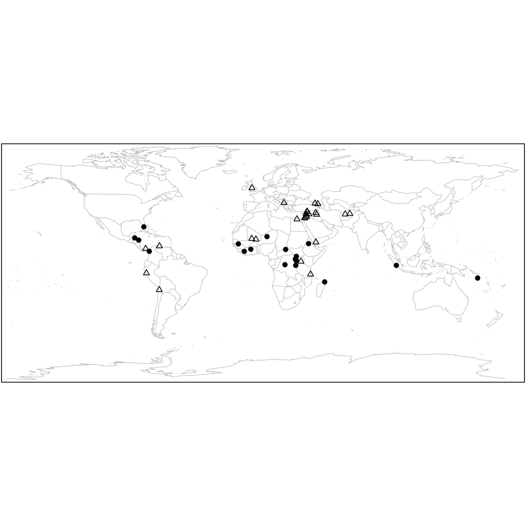

```r
> # plot endangered heritage sites
> # pdf(file="heritage-map.pdf", height=3.3, width=7, family="URWTimes")
> par(oma=c(0,0,0,0))
> par(mar=c(0,0,0,0))
> pch <- ifelse(danger_table$crit == "nat", 19, 2)
> map("world", col = "darkgrey", lwd = .5, mar = c(0.1,0.1,0.1,0.1))
> points(danger_table$x_coords, danger_table$y_coords, pch = pch, col = "black", cex = .8)
> box()
```

```r
> # dev.off()
```

We find that many of the endangered sites are located in Africa, the Middle East, and Southwest Asia, and a few others in South and Central America. The endangered cultural heritage sites are visualized as the triangle. They tend to be clustered in the Middle East and Southwest Asia. Conversely, the natural heritage sites in danger, here visualized as the dots, are more prominent in Africa.

We find that there are more cultural than natural sites in danger.

```r
> # table heritage criteria
> table(danger_table$crit)
```

```
cult  nat
  26   18
```

Other plots can be done such as year of endangerment

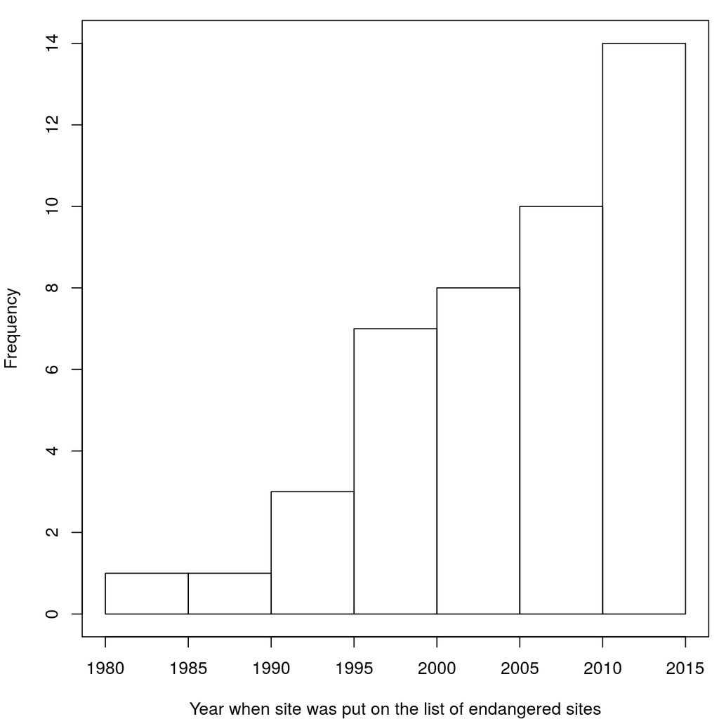

```r
> #pdf(file="heritage-hist1.pdf", height=3.3, width=7, family="URWTimes")
> par(oma=c(0,0,0,0))
> par(mar=c(4,4,1,.5))
> hist(danger_table$yend, freq=TRUE, xlab="Year when site was put on the list of endangered sites", main="")
> box()
```

```r
> #dev.off()
```

We can plot time between inscription and endangerment

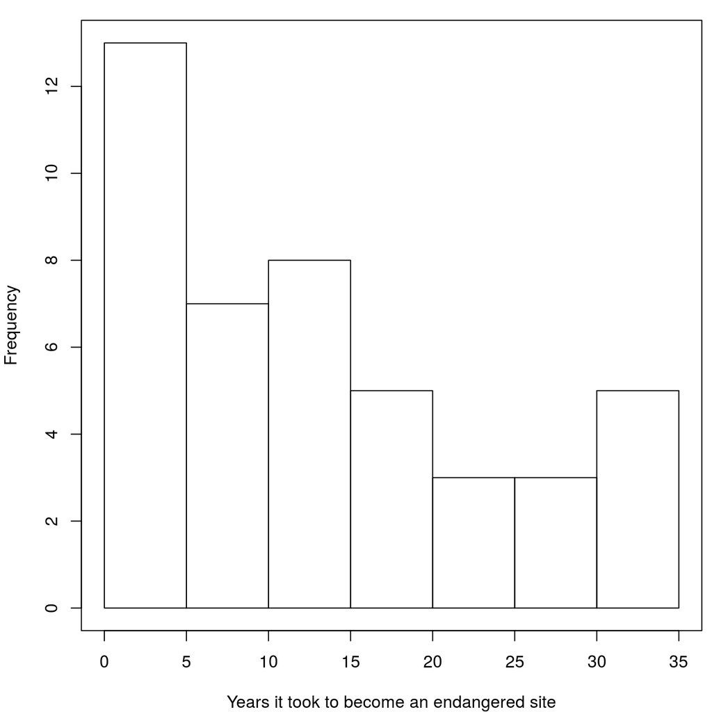

```r
> duration <- danger_table$yend - danger_table$yins
> #pdf(file="heritage-hist2.pdf", height=3.3, width=7, family="URWTimes")
> par(oma=c(0,0,0,0))
> par(mar=c(4,4,1,.5))
> hist(duration, freq=TRUE, xlab="Years it took to become an endangered site", main="")
> box()
```

```r
> #dev.off()
```